# Nanodegree Engenheiro de Machine Learning

## Utilização de aprendizado não supervisionado para melhorar gameplay em League of Legends

Cada vez mais os *e-sports* (esportes eletrônicos) vem ganhando mais espaço no mundo e atingindo um grande número de pessoas ao redor do mundo. Esse “boom” fez com que crescessem ainda mais a quantidade de eventos realizados em todo o planeta e também fez com que os investimentos sobre estes alcançassem a casa de milhões de reais [[1]](https://economia.uol.com.br/noticias/redacao/2019/01/20/esports-crescimento-mercado-campeonatos-torneios.htm]). Curiosamente, ou não, eu sou uma dessas pessoas fissuradas em *e-sports*, sobretudo em um especial chamado League of Legends.

Jogo regularmente o League of Legends, também conhecimento carinhosamente como LoL, desde 2014 e de lá pra cá venho a cada dia tentando melhorar a minha *gameplay* (ou jogabilidade) e desenvolvendo novas estratégias para me tornar melhor. A partir daqui então este projeto é iniciado, pois o intuito dele é utilizar *machine learning*, aprendizado não supervisionado, para entender mais sobre os resultados das minhas partidas e me ajudar a melhorar o meu *gameplay*.

Para isto utilizei dados das minhas 100 últimas partidas disputadas no LoL. Estes dados que compõem o *dataset* utilizado neste projeto foram extraídos a partir da [API](https://developer.riotgames.com/) disponibilizada pela Riot (empresa dona do League of Legends), para todos aqueles que queiram acessar determinados dados de partidas e de jogadores (nem todos os dados existentes são disponibilizados).

**Mãos à obra!**

## Importação de bibliotecas iniciais

Importação de algumas bibliotecas iniciais. Ao decorrer do projeto serão importadas mais bibliotecas necessárias.

```python
import pandas as pd
import requests
from requests.exceptions import BaseHTTPError
import io
import sys, json
import numpy as np
from riotwatcher import RiotWatcher, ApiError
import my_lol_functions as mlf
```

## Definindo perfil de acesso

Para tornar possível o acesso aos dados do League of Legends disponibilizados através da API há a necessidade de realizar alguns passos previamente, sendo estes o cadastro no [portal do desenvolvedor](https://developer.riotgames.com/), uma leitura na [documentação da API](https://developer.riotgames.com/api-methods/) para melhor entendimento de cada uma das disponibilizadas e por fim gerar um **DEVELOPMENT API KEY** no portal do desenvolvedor.

O Development API Key é uma chave temporária necessária para realizar o acesso nos dados do LoL e também é uma forma da Riot controlar esse acesso, colocando inclusive um limite de quantidade de dados resgatado por tempo. Neste projeto utilizei um *wrapper* chamado [RiotWatcher](https://riot-watcher.readthedocs.io/en/latest/) que utiliza a API da Riot para recuperar os dados. O motivo de utilizá-lo é porque ele já possui as funções de acesso e extração prontas, facilitando o trabalho a ser realizado.

Abaixo recupero o meu `accountId`, necessário para identificação e extração dos meus dados. Para isto uso o Development API Key na primeira linha e depois passo a região do servidor que jogo e o meu nickname.

```python
watcher = RiotWatcher('RGAPI-7bf63dd8-e11c-4b8d-b5e1-ac25f3563064')
my_region = 'br1'
nickname = 'ElFeRtOn'

me = watcher.summoner.by_name(my_region, nickname)
account_id = me['accountId']
```

## Extração e modelagem de dados

Abaixo iniciaremos a extração. Para isto utilizei uma função que criei chamada `get_dados` (para detalhes da implementação basta abrir o arquivo `my_lol_functions.py` presente no diretório do projeto) que carrega os dados disponibilizados no formato `.json` em um data frame do pandas.

Também carrego estes dados no arquivo `data.csv` para estes serem utilizados posteriormente em uma outra etapa.

```python
df = mlf.get_dados(watcher, my_region, account_id, nickname)
df.to_csv('data.csv', index = None, header=True)

df.head()
```

|  | win | kills | deaths | assists | largestKillingSpree | largestMultiKill | killingSprees | longestTimeSpentLiving | totalDamageDealt | trueDamageDealt | ... | firstBloodKill | firstBloodAssist | firstTowerKill | firstTowerAssist | firstInhibitorKill | firstInhibitorAssist | KDA | gameDuration | red_team | blue_team |
| --- | --- | --- | --- | --- | --- | --- | --- | --- | --- | --- | --- | --- | --- | --- | --- | --- | --- | --- | --- | --- | --- |
| 0 | 0 | 0 | 2 | 0 | 0 | 0 | 0 | 603 | 38875 | 0 | ... | 0 | 0 | 0 | 0 | 0 | 0 | 0 | 1125 | 1 | 0 |
| 1 | 0 | 8 | 2 | 13 | 8 | 1 | 1 | 1766 | 154552 | 4020 | ... | 0 | 0 | 0 | 0 | 0 | 1 | 10 | 1899 | 1 | 0 |
| 2 | 0 | 8 | 7 | 13 | 5 | 1 | 2 | 1333 | 134638 | 196 | ... | 0 | 0 | 0 | 0 | 0 | 0 | 3 | 2233 | 1 | 0 |
| 3 | 0 | 6 | 5 | 11 | 2 | 1 | 3 | 521 | 179346 | 26417 | ... | 0 | 0 | 0 | 0 | 0 | 0 | 3 | 2097 | 1 | 0 |
| 4 | 1 | 7 | 1 | 11 | 5 | 1 | 2 | 1225 | 101646 | 853 | ... | 0 | 0 | 0 | 0 | 0 | 0 | 18 | 1509 | 1 | 0 |

5 rows × 43 columns

## Explorando os dados

Para a realização do trabalho foram selecionadas 43 *features* dentre todas as oferecidas pela api da Riot. Estas foram selecionadas mediante o conhecimento prévio da regra de negócio do jogo e também pelo fato da grande maioria destas serem variáveis numéricas. São as características escolhidas para a solução deste problema:

```python
df.columns
```

```
Index(['win', 'kills', 'deaths', 'assists', 'largestKillingSpree',
       'largestMultiKill', 'killingSprees', 'longestTimeSpentLiving',
       'totalDamageDealt', 'trueDamageDealt', 'totalDamageDealtToChampions',
       'trueDamageDealtToChampions', 'totalHeal', 'totalUnitsHealed',
       'damageSelfMitigated', 'damageDealtToObjectives',
       'damageDealtToTurrets', 'visionScore', 'totalDamageTaken', 'goldEarned',
       'goldSpent', 'turretKills', 'inhibitorKills', 'totalMinionsKilled',
       'neutralMinionsKilled', 'neutralMinionsKilledTeamJungle',
       'neutralMinionsKilledEnemyJungle', 'totalTimeCrowdControlDealt',
       'champLevel', 'visionWardsBoughtInGame', 'sightWardsBoughtInGame',
       'wardsPlaced', 'wardsKilled', 'firstBloodKill', 'firstBloodAssist',
       'firstTowerKill', 'firstTowerAssist', 'firstInhibitorKill',
       'firstInhibitorAssist', 'KDA', 'gameDuration', 'red_team', 'blue_team'],
      dtype='object')
```

No arquivo `README.md`, presente no diretório deste projeto, há um pequeno dicionário de dados sobre estes atributos para melhor entendimento. Abaixo exibo uma pequena estatística sobre cada uma das features. Vale notar que apesar de alguns atributos serem numéricos eles são de natureza booleana, como por exemplo o `win` (1 em caso positivo - vitória e 0 em caso negativo - derrota).

```python
df.describe()
```

|  | win | kills | deaths | assists | largestKillingSpree | largestMultiKill | killingSprees | longestTimeSpentLiving | totalDamageDealt | trueDamageDealt | ... | firstBloodKill | firstBloodAssist | firstTowerKill | firstTowerAssist | firstInhibitorKill | firstInhibitorAssist | KDA | gameDuration | red_team | blue_team |
| --- | --- | --- | --- | --- | --- | --- | --- | --- | --- | --- | --- | --- | --- | --- | --- | --- | --- | --- | --- | --- | --- |
| count | 100.000000 | 100.000000 | 100.000000 | 100.000000 | 100.00000 | 100.00 | 100.000000 | 100.000000 | 100.000000 | 100.000000 | ... | 100.00000 | 100.0 | 100.000000 | 100.000000 | 100.000000 | 100.000000 | 100.000000 | 100.000000 | 100.00000 | 100.00000 |
| mean | 0.490000 | 6.500000 | 4.610000 | 7.870000 | 3.36000 | 1.43 | 1.550000 | 737.480000 | 142165.210000 | 12771.430000 | ... | 0.08000 | 0.0 | 0.090000 | 0.110000 | 0.100000 | 0.190000 | 4.400000 | 1768.050000 | 0.57000 | 0.43000 |
| std | 0.502418 | 4.284103 | 2.870593 | 5.016448 | 2.44751 | 0.70 | 1.233988 | 375.688257 | 63599.052264 | 30864.219644 | ... | 0.27266 | 0.0 | 0.287623 | 0.314466 | 0.301511 | 0.394277 | 5.367316 | 456.631482 | 0.49757 | 0.49757 |
| min | 0.000000 | 0.000000 | 0.000000 | 0.000000 | 0.00000 | 0.00 | 0.000000 | 0.000000 | 3551.000000 | 0.000000 | ... | 0.00000 | 0.0 | 0.000000 | 0.000000 | 0.000000 | 0.000000 | 0.000000 | 195.000000 | 0.00000 | 0.00000 |
| 25% | 0.000000 | 3.000000 | 3.000000 | 4.000000 | 2.00000 | 1.00 | 1.000000 | 527.250000 | 101465.750000 | 3852.500000 | ... | 0.00000 | 0.0 | 0.000000 | 0.000000 | 0.000000 | 0.000000 | 1.000000 | 1498.250000 | 0.00000 | 0.00000 |
| 50% | 0.000000 | 6.000000 | 4.000000 | 7.000000 | 3.00000 | 1.00 | 1.000000 | 654.500000 | 138517.500000 | 9016.500000 | ... | 0.00000 | 0.0 | 0.000000 | 0.000000 | 0.000000 | 0.000000 | 3.000000 | 1786.000000 | 1.00000 | 0.00000 |
| 75% | 1.000000 | 9.000000 | 7.000000 | 10.250000 | 5.00000 | 2.00 | 2.000000 | 962.750000 | 179671.500000 | 14503.000000 | ... | 0.00000 | 0.0 | 0.000000 | 0.000000 | 0.000000 | 0.000000 | 5.000000 | 2074.250000 | 1.00000 | 1.00000 |
| max | 1.000000 | 21.000000 | 16.000000 | 25.000000 | 11.00000 | 4.00 | 7.000000 | 1766.000000 | 329905.000000 | 309196.000000 | ... | 1.00000 | 0.0 | 1.000000 | 1.000000 | 1.000000 | 1.000000 | 30.000000 | 2916.000000 | 1.00000 | 1.00000 |

8 rows × 43 columns

Olhando para estas estatísticas acima podemos conhecer um pouco melhor sobre o conjunto de dados que iremos utilizar e já extrair alguns conhecimentos importantes, como por exemplo:

- O conjunto de dados é composto por uma quantidade de 100 registros, ou seja, **100 partidas** jogadas;
- Das 100 partidas disputadas, **49 foram vitórias** e automaticamente **51 derrotas**;
- A quantidade média de `kills`, `deaths` e `assists` destes 100 jogos é de `6.5`, `4.61` e `7.87` respectivamente. O `KDA` médio é de `4.4`;
- Os maiores números de `kills`, `deaths` e `assists` que já obtive em uma partida foram de `21`, `16` (nossa, acho que "trollei" nesse jogo) e `25` respectivamente. Isto não quer dizer que estes números foram todos de uma mesma partida, pelo contrário, dificilmente foram;
- As minhas partidas duram em média `1768.05` segundos ou aproximadamente **29,46 minutos**.

Essas estatísticas, mesmo que simples, já podem dizer um pouco sobre o tipo de jogador que sou. Por exemplo: procuro morrer pouco nas partidas (considero `4,61` um valor relativamente baixo para as `deaths`); o meu número de `assists` é ligeiramente maior que o meu número de `kills`, o que pode indicar que jogo em uma posição em que ajudo mais do que "carrego" o time, no sentido de eu não ser a referência; e também que as partidas que jogo estão dentro do esperado para o *patch* atual do jogo, uma vez que a média é **29,46 minutos**.

## Relevância dos atributos

Como há uma grande quantidade de atributos, um total de 43, foi proposto utilizar o classificador do algoritmo de **Random Forest** para identificação das 10 *features* mais importantes e seus respectivos pesos. Após a identificação foi gerado um novo data frame a partir do anterior apenas com os 10 principais atributos.

```python
from sklearn.model_selection import train_test_split
from sklearn.ensemble import RandomForestClassifier

# Exclusão da feature que identifica se o resultado do jogo foi ou não uma vitória
new_data = df.drop(['win'], axis = 1)

# Dividir os dados em conjuntos de treinamento e teste utilizando o atributo dado como o alvo
X_train, X_test, y_train, y_test = train_test_split(new_data, df['win'], test_size=0.25, random_state=50)

# Treinar o modelo utilizando o conjunto de treinamento com .fit(X_train, y_train)
model = RandomForestClassifier(random_state = 100).fit(X_train, y_train)

# Extrair a importância dos atributos utilizando .feature_importances_
importances = model.feature_importances_

# Ordena por ordem de importância os índices das features
indices = np.argsort(importances)[::-1]

# Imprime as 10 features mais importantes e os valores de importância
for i in range(10):
    print('Feature/Weight:', X_train.columns.values[indices[i]],'- {:.4f}%' .format(importances[indices[i]]))
```

```
Feature/Weight: KDA - 0.1437%
Feature/Weight: damageDealtToTurrets - 0.1377%
Feature/Weight: deaths - 0.0836%
Feature/Weight: damageDealtToObjectives - 0.0775%
Feature/Weight: totalHeal - 0.0500%
Feature/Weight: totalMinionsKilled - 0.0413%
Feature/Weight: totalDamageDealt - 0.0412%
Feature/Weight: longestTimeSpentLiving - 0.0394%
Feature/Weight: assists - 0.0392%
Feature/Weight: inhibitorKills - 0.0355%
```

```python
# Grava em um novo data frame os dado com apenas as 10 features mais importantes
data = new_data[X_train.columns.values[indices[:10]]]

data.head()
```

|  | KDA | damageDealtToTurrets | deaths | damageDealtToObjectives | totalHeal | totalMinionsKilled | totalDamageDealt | longestTimeSpentLiving | assists | inhibitorKills |
| --- | --- | --- | --- | --- | --- | --- | --- | --- | --- | --- |
| 0 | 0 | 706 | 2 | 706 | 470 | 92 | 38875 | 603 | 0 | 0 |
| 1 | 10 | 6635 | 2 | 10974 | 3777 | 180 | 154552 | 1766 | 13 | 0 |
| 2 | 3 | 4193 | 7 | 4193 | 5112 | 192 | 134638 | 1333 | 13 | 0 |
| 3 | 3 | 3716 | 5 | 3716 | 2892 | 181 | 179346 | 521 | 11 | 0 |
| 4 | 18 | 5105 | 1 | 7309 | 3029 | 146 | 101646 | 1225 | 11 | 0 |

A seguir são exibidas uma matriz de dispersão, um *heatmap* e uma tabela cruzada a afim de mostrar como é a correlação entre as 10 principais features escolhidas. É importante notar através desses meios que não existe nenhum par de atributos com uma alta correção, porém existem alguns pares que possuem correlações razoáveis, como por exemplo:

- (totalHeal,damageDealtToObjectives) = 0.602457
- (totalDamageDealt,damageDealtToObjectives) = 0.563822
- (totalHeal,totalDamageDealt) = 0.550093
- (damageDealtToTurrets,totalMinionsKilled) = 0.542863

Como pode ser percebido o atributo de `totalHeal` tem boa correlação com `totalDamageDealt` e `damageDealtToObjectives`, fazendo com que automaticamente estes dois últimos atributos também possuam uma boa correlação entre si. Inclusive faz sentido os atributos `totalDamageDealt` e `damageDealtToObjectives` possuírem correlação, uma vez que o segundo atributo compõe o primeiro. Achei interessante também a correlação entre `damageDealtToTurrets` e `totalMinionsKilled`, pois pensando no jogo e em sua fase de rotas, quanto mais minions você abater mais a rota será "puxada" e maior a possibilidade de você causar dano a torres.

**Observação:** lembrando que os valores de correlação entre os pares de atributos podem variar de -1 até 1, onde quanto mais próximo do -1 indica baixa correlação e quanto mais próximo do 1 indica alta correlação.

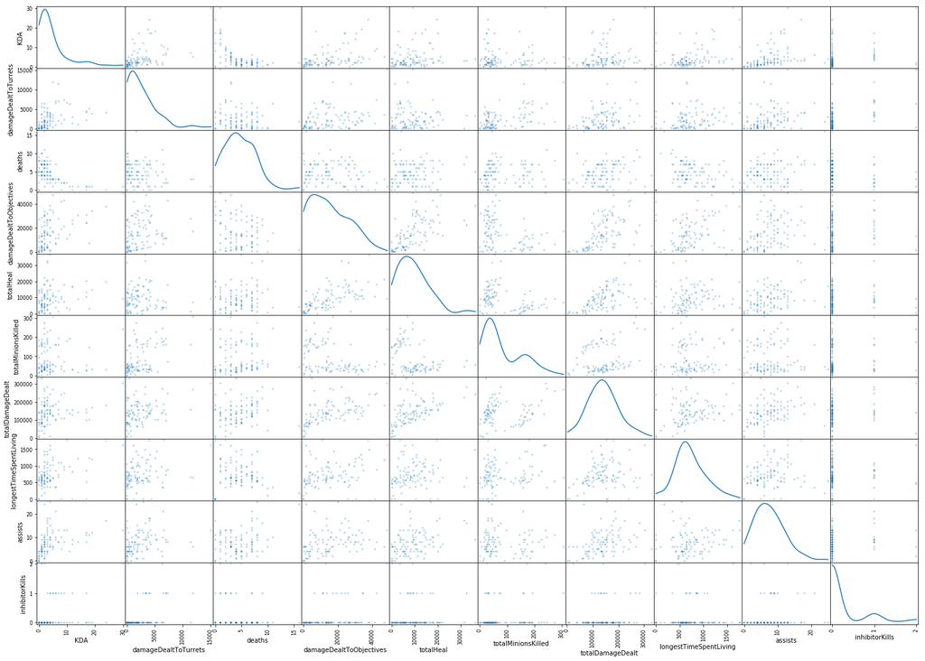

```python
# Matriz de dispersão para cada um dos pares de atributos dos dados
pd.plotting.scatter_matrix(data, alpha = 0.3, figsize = (25,18), diagonal = 'kde');
```

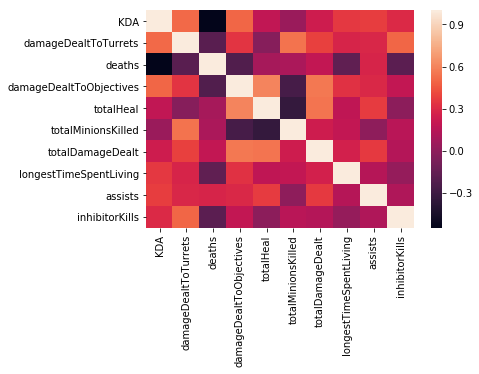

```python
import seaborn as sns

# Criação do heatmap com a correlação entre os pares de atributos
sns.heatmap(data.corr())
```

```python
# tabela cruzada entre os pares de atributos com o valor de correção entre eles
data.corr()
```

|  | KDA | damageDealtToTurrets | deaths | damageDealtToObjectives | totalHeal | totalMinionsKilled | totalDamageDealt | longestTimeSpentLiving | assists | inhibitorKills |
| --- | --- | --- | --- | --- | --- | --- | --- | --- | --- | --- |
| KDA | 1.000000 | 0.513057 | -0.548996 | 0.501706 | 0.188484 | 0.045891 | 0.232740 | 0.358407 | 0.375231 | 0.299187 |
| damageDealtToTurrets | 0.513057 | 1.000000 | -0.188034 | 0.346419 | -0.024963 | 0.542863 | 0.388351 | 0.279638 | 0.291508 | 0.498143 |
| deaths | -0.548996 | -0.188034 | 1.000000 | -0.220480 | 0.090481 | 0.106204 | 0.190128 | -0.166909 | 0.274919 | -0.184266 |
| damageDealtToObjectives | 0.501706 | 0.346419 | -0.220480 | 1.000000 | 0.602457 | -0.262724 | 0.563822 | 0.330597 | 0.295709 | 0.189932 |
| totalHeal | 0.188484 | -0.024963 | 0.090481 | 0.602457 | 1.000000 | -0.331883 | 0.550093 | 0.181516 | 0.365807 | -0.000893 |
| totalMinionsKilled | 0.045891 | 0.542863 | 0.106204 | -0.262724 | -0.331883 | 1.000000 | 0.234712 | 0.192454 | 0.003782 | 0.157761 |
| totalDamageDealt | 0.232740 | 0.388351 | 0.190128 | 0.563822 | 0.550093 | 0.234712 | 1.000000 | 0.257726 | 0.360759 | 0.139362 |
| longestTimeSpentLiving | 0.358407 | 0.279638 | -0.166909 | 0.330597 | 0.181516 | 0.192454 | 0.257726 | 1.000000 | 0.145121 | 0.027441 |
| assists | 0.375231 | 0.291508 | 0.274919 | 0.295709 | 0.365807 | 0.003782 | 0.360759 | 0.145121 | 1.000000 | 0.120218 |
| inhibitorKills | 0.299187 | 0.498143 | -0.184266 | 0.189932 | -0.000893 | 0.157761 | 0.139362 | 0.027441 | 0.120218 | 1.000000 |

## Pré-processamento de Dados

A seguir será realizado um pré-processamento dos dados para criar uma melhor representação das partidas ao executar um escalonamento dos dados e detecção dos discrepantes.

### Escalonando Atributos

O escolonamento de atributos é importante sobretudo quando os dados não estão distribuídos normalmente. Neste projeto será aplicado um logaritmo através da função do `log` do `numpy` para a realização do escalonamento. Após a aplicação desta estratégia será exibida novamente a matriz de dispersão.

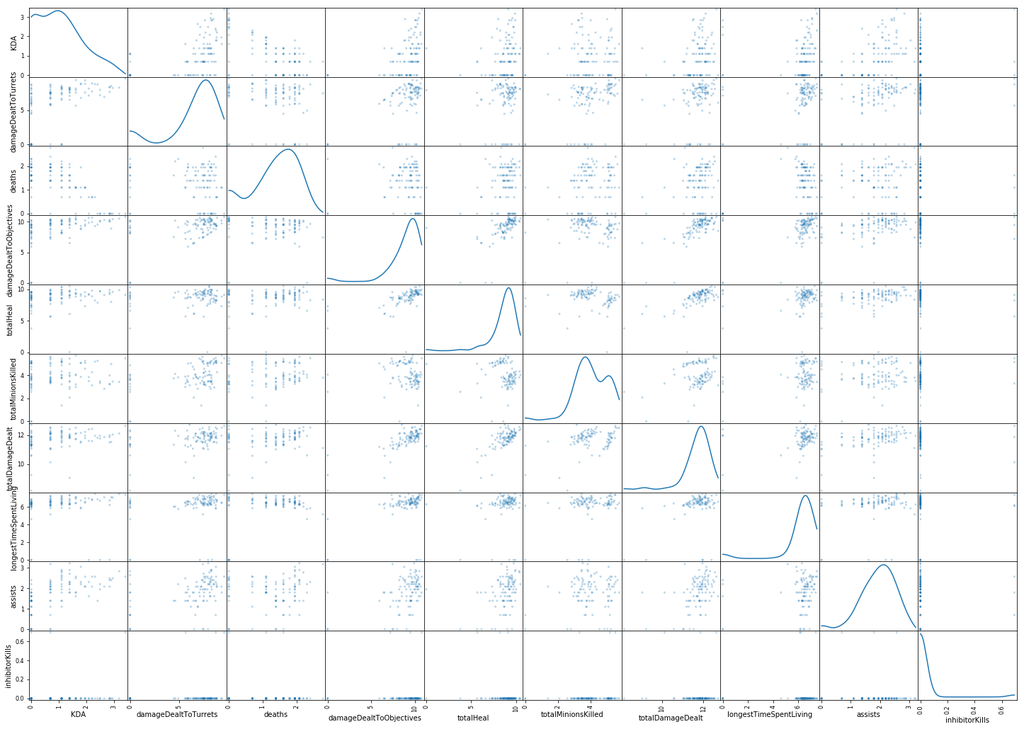

```python
# Dados escalonados utilizando logaritmo
log_data = np.log(data)
# Como o valor de log(0) é igual a -inf foi substituído por 0 para não deixar esse valor
log_data = log_data.replace(np.log(0),0)

# Matriz de dispersão para cada par de atributos novos-transformados
pd.plotting.scatter_matrix(log_data, alpha = 0.3, figsize = (25,18), diagonal = 'kde');
```

A seguir é realizada a etapa para detecção dos dados discrepantes, também chamado de *outliers*. São exibidos aqueles considerados como *outliers* para cada um dos atributos e também aqueles que aparecem para mais um de atributo. Foi considerado retirar esses dados discrepantes armazenando em um novo data frame chamado `good_data` apenas os dados considerados como bons.

```python
outliers  = []
outliers_many_times = []
for feature in log_data.keys():

    # Q1 (25º percentil dos dados) para o atributo dado
    Q1 = np.percentile(log_data[feature],25)

    # Q3 (75º percentil dos dados) para o atributo dado
    Q3 = np.percentile(log_data[feature],75)

    # Amplitude interquartil para calcular o passo do discrepante (1,5 vezes a variação interquartil)
    step = 1.5 * (Q3 - Q1)

    # Mostre os discrepantes
    print("Pontos de dados considerados outliers para o atributo '{}':".format(feature))
    feature_outlier = log_data[~((log_data[feature] >= Q1 - step) & (log_data[feature] <= Q3 + step))]
    display(feature_outlier)

    # Seleção dos índices dos pontos de dados que serão removidos
    for i in feature_outlier.index:
        if i in outliers and i not in outliers_many_times:
            outliers_many_times.append(i)
        if i not in outliers:
            outliers.append(i)

print("Outlier index:", outliers)
print("Outliers mais de uma vez: ", outliers_many_times)

# Criação de um novo data set apenas com os dados considerados bons
good_data = log_data.drop(log_data.index[outliers]).reset_index(drop = True)
```

```
Pontos de dados considerados outliers para o atributo 'KDA':
```

|  | KDA | damageDealtToTurrets | deaths | damageDealtToObjectives | totalHeal | totalMinionsKilled | totalDamageDealt | longestTimeSpentLiving | assists | inhibitorKills |
| --- | --- | --- | --- | --- | --- | --- | --- | --- | --- | --- |

```
Pontos de dados considerados outliers para o atributo 'damageDealtToTurrets':
```

|  | KDA | damageDealtToTurrets | deaths | damageDealtToObjectives | totalHeal | totalMinionsKilled | totalDamageDealt | longestTimeSpentLiving | assists | inhibitorKills |
| --- | --- | --- | --- | --- | --- | --- | --- | --- | --- | --- |
| 14 | 0.000000 | 0.0 | 2.079442 | 9.355393 | 8.765146 | 3.688879 | 11.859970 | 6.345636 | 0.693147 | 0.0 |
| 15 | 1.098612 | 0.0 | 0.693147 | 8.074026 | 7.703910 | 4.875197 | 11.188621 | 6.437752 | 1.098612 | 0.0 |
| 29 | 1.098612 | 0.0 | 1.945910 | 10.174087 | 10.358853 | 3.828641 | 12.323900 | 5.908083 | 2.833213 | 0.0 |
| 33 | 0.000000 | 0.0 | 1.386294 | 9.058587 | 9.017241 | 2.772589 | 11.339964 | 6.489205 | 0.000000 | 0.0 |
| 38 | 0.000000 | 0.0 | 0.000000 | 0.000000 | 7.300473 | 0.000000 | 9.248118 | 0.000000 | 0.000000 | 0.0 |
| 46 | 1.098612 | 0.0 | 1.945910 | 10.191857 | 9.516206 | 4.007333 | 12.244408 | 6.955593 | 2.639057 | 0.0 |
| 54 | 0.000000 | 0.0 | 2.302585 | 0.000000 | 6.597146 | 4.060443 | 10.600552 | 4.624973 | 1.791759 | 0.0 |
| 80 | 0.000000 | 0.0 | 1.098612 | 8.250359 | 8.588024 | 0.000000 | 11.269362 | 6.152733 | 0.693147 | 0.0 |
| 81 | 0.000000 | 0.0 | 1.609438 | 8.177516 | 8.910856 | 3.610918 | 11.351112 | 6.690842 | 0.693147 | 0.0 |
| 83 | 0.000000 | 0.0 | 1.945910 | 9.015055 | 9.469777 | 3.258097 | 11.838662 | 6.711740 | 1.386294 | 0.0 |
| 86 | 0.000000 | 0.0 | 0.000000 | 0.000000 | 3.784190 | 2.564949 | 8.174985 | 0.000000 | 0.000000 | 0.0 |
| 94 | 0.000000 | 0.0 | 1.609438 | 8.506537 | 8.440096 | 2.995732 | 11.375799 | 5.978886 | 1.791759 | 0.0 |
| 96 | 0.693147 | 0.0 | 1.945910 | 9.992139 | 9.185433 | 3.610918 | 11.718101 | 6.565265 | 2.197225 | 0.0 |

```
Pontos de dados considerados outliers para o atributo 'deaths':
```

|  | KDA | damageDealtToTurrets | deaths | damageDealtToObjectives | totalHeal | totalMinionsKilled | totalDamageDealt | longestTimeSpentLiving | assists | inhibitorKills |
| --- | --- | --- | --- | --- | --- | --- | --- | --- | --- | --- |

```
Pontos de dados considerados outliers para o atributo 'damageDealtToObjectives':
```

|  | KDA | damageDealtToTurrets | deaths | damageDealtToObjectives | totalHeal | totalMinionsKilled | totalDamageDealt | longestTimeSpentLiving | assists | inhibitorKills |
| --- | --- | --- | --- | --- | --- | --- | --- | --- | --- | --- |
| 7 | 0.0 | 5.937536 | 2.079442 | 5.937536 | 7.059618 | 5.036953 | 11.187528 | 6.289716 | 1.386294 | 0.0 |
| 38 | 0.0 | 0.000000 | 0.000000 | 0.000000 | 7.300473 | 0.000000 | 9.248118 | 0.000000 | 0.000000 | 0.0 |
| 54 | 0.0 | 0.000000 | 2.302585 | 0.000000 | 6.597146 | 4.060443 | 10.600552 | 4.624973 | 1.791759 | 0.0 |
| 86 | 0.0 | 0.000000 | 0.000000 | 0.000000 | 3.784190 | 2.564949 | 8.174985 | 0.000000 | 0.000000 | 0.0 |

```
Pontos de dados considerados outliers para o atributo 'totalHeal':
```

|  | KDA | damageDealtToTurrets | deaths | damageDealtToObjectives | totalHeal | totalMinionsKilled | totalDamageDealt | longestTimeSpentLiving | assists | inhibitorKills |
| --- | --- | --- | --- | --- | --- | --- | --- | --- | --- | --- |
| 0 | 0.000000 | 6.559615 | 0.693147 | 6.559615 | 6.152733 | 4.521789 | 10.568107 | 6.401917 | 0.000000 | 0.000000 |
| 6 | 0.693147 | 7.533159 | 0.000000 | 7.533159 | 5.655992 | 5.003946 | 11.052064 | 6.161207 | 0.000000 | 0.000000 |
| 10 | 1.386294 | 7.916078 | 1.098612 | 9.012986 | 0.000000 | 4.976734 | 11.226336 | 6.308098 | 1.945910 | 0.000000 |
| 52 | 1.386294 | 6.516193 | 0.693147 | 6.516193 | 6.095825 | 2.079442 | 9.053687 | 5.860786 | 1.791759 | 0.000000 |
| 54 | 0.000000 | 0.000000 | 2.302585 | 0.000000 | 6.597146 | 4.060443 | 10.600552 | 4.624973 | 1.791759 | 0.000000 |
| 75 | 0.693147 | 5.680173 | 1.098612 | 7.206377 | 5.686975 | 3.295837 | 10.126671 | 6.113682 | 1.791759 | 0.693147 |
| 86 | 0.000000 | 0.000000 | 0.000000 | 0.000000 | 3.784190 | 2.564949 | 8.174985 | 0.000000 | 0.000000 | 0.000000 |

```
Pontos de dados considerados outliers para o atributo 'totalMinionsKilled':
```

|  | KDA | damageDealtToTurrets | deaths | damageDealtToObjectives | totalHeal | totalMinionsKilled | totalDamageDealt | longestTimeSpentLiving | assists | inhibitorKills |
| --- | --- | --- | --- | --- | --- | --- | --- | --- | --- | --- |
| 38 | 0.0 | 0.0 | 0.000000 | 0.000000 | 7.300473 | 0.0 | 9.248118 | 0.000000 | 0.000000 | 0.0 |
| 80 | 0.0 | 0.0 | 1.098612 | 8.250359 | 8.588024 | 0.0 | 11.269362 | 6.152733 | 0.693147 | 0.0 |

```
Pontos de dados considerados outliers para o atributo 'totalDamageDealt':
```

|  | KDA | damageDealtToTurrets | deaths | damageDealtToObjectives | totalHeal | totalMinionsKilled | totalDamageDealt | longestTimeSpentLiving | assists | inhibitorKills |
| --- | --- | --- | --- | --- | --- | --- | --- | --- | --- | --- |
| 0 | 0.000000 | 6.559615 | 0.693147 | 6.559615 | 6.152733 | 4.521789 | 10.568107 | 6.401917 | 0.000000 | 0.000000 |
| 38 | 0.000000 | 0.000000 | 0.000000 | 0.000000 | 7.300473 | 0.000000 | 9.248118 | 0.000000 | 0.000000 | 0.000000 |
| 52 | 1.386294 | 6.516193 | 0.693147 | 6.516193 | 6.095825 | 2.079442 | 9.053687 | 5.860786 | 1.791759 | 0.000000 |
| 54 | 0.000000 | 0.000000 | 2.302585 | 0.000000 | 6.597146 | 4.060443 | 10.600552 | 4.624973 | 1.791759 | 0.000000 |
| 75 | 0.693147 | 5.680173 | 1.098612 | 7.206377 | 5.686975 | 3.295837 | 10.126671 | 6.113682 | 1.791759 | 0.693147 |
| 86 | 0.000000 | 0.000000 | 0.000000 | 0.000000 | 3.784190 | 2.564949 | 8.174985 | 0.000000 | 0.000000 | 0.000000 |

```
Pontos de dados considerados outliers para o atributo 'longestTimeSpentLiving':
```

|  | KDA | damageDealtToTurrets | deaths | damageDealtToObjectives | totalHeal | totalMinionsKilled | totalDamageDealt | longestTimeSpentLiving | assists | inhibitorKills |
| --- | --- | --- | --- | --- | --- | --- | --- | --- | --- | --- |
| 17 | 2.079442 | 7.138073 | 0.000000 | 10.638976 | 9.263028 | 3.850148 | 12.390425 | 0.000000 | 1.609438 | 0.0 |
| 32 | 2.833213 | 8.392537 | 0.000000 | 10.333092 | 9.911753 | 3.258097 | 11.973939 | 0.000000 | 2.397895 | 0.0 |
| 36 | 2.484907 | 7.977968 | 0.000000 | 10.166967 | 9.736311 | 3.465736 | 11.951129 | 0.000000 | 2.197225 | 0.0 |
| 38 | 0.000000 | 0.000000 | 0.000000 | 0.000000 | 7.300473 | 0.000000 | 9.248118 | 0.000000 | 0.000000 | 0.0 |
| 54 | 0.000000 | 0.000000 | 2.302585 | 0.000000 | 6.597146 | 4.060443 | 10.600552 | 4.624973 | 1.791759 | 0.0 |
| 86 | 0.000000 | 0.000000 | 0.000000 | 0.000000 | 3.784190 | 2.564949 | 8.174985 | 0.000000 | 0.000000 | 0.0 |
| 97 | 0.693147 | 7.455877 | 2.772589 | 7.455877 | 8.366138 | 3.806662 | 11.104175 | 5.164786 | 3.178054 | 0.0 |

```
Pontos de dados considerados outliers para o atributo 'assists':
```

|  | KDA | damageDealtToTurrets | deaths | damageDealtToObjectives | totalHeal | totalMinionsKilled | totalDamageDealt | longestTimeSpentLiving | assists | inhibitorKills |
| --- | --- | --- | --- | --- | --- | --- | --- | --- | --- | --- |

```
Pontos de dados considerados outliers para o atributo 'inhibitorKills':
```

|  | KDA | damageDealtToTurrets | deaths | damageDealtToObjectives | totalHeal | totalMinionsKilled | totalDamageDealt | longestTimeSpentLiving | assists | inhibitorKills |
| --- | --- | --- | --- | --- | --- | --- | --- | --- | --- | --- |
| 67 | 0.000000 | 8.763115 | 1.609438 | 9.485849 | 8.238273 | 5.153292 | 11.857260 | 6.204558 | 0.693147 | 0.693147 |
| 75 | 0.693147 | 5.680173 | 1.098612 | 7.206377 | 5.686975 | 3.295837 | 10.126671 | 6.113682 | 1.791759 | 0.693147 |
| 89 | 3.401197 | 9.626284 | 0.000000 | 10.796203 | 9.128479 | 5.484797 | 12.623796 | 7.390799 | 2.564949 | 0.693147 |

```
Outlier index: [14, 15, 29, 33, 38, 46, 54, 80, 81, 83, 86, 94, 96, 7, 0, 6, 10, 52, 75, 17, 32, 36, 97, 67, 89]
Outliers mais de uma vez:  [38, 54, 86, 80, 0, 52, 75]
```

## Transformação de Atributo

Nesta etapa iremos realizar dois procedimentos importantes, sendos estes a identificação dos PCA's e a redução de dimensionalidade. O primeiro irá nos ajudar a entender melhor a variância ocorrida em cada dimensão encontrada e o segundo nos ajudará a diminuir a complexidade do problema.

### Implementação: PCA

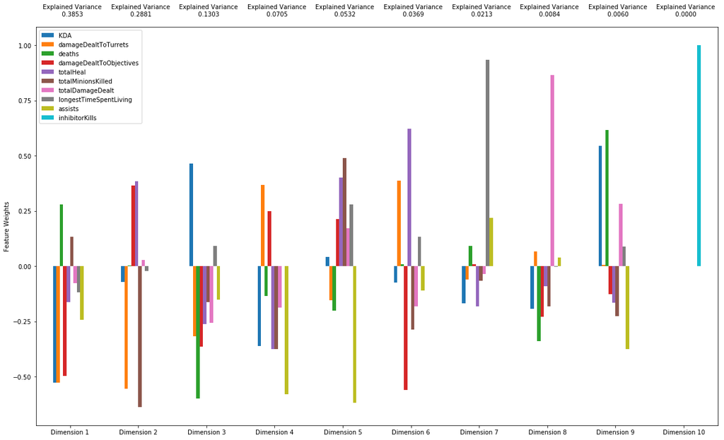

```python
from sklearn.decomposition import PCA
import visuals as vs

# Aplicação do PCA nos bons dados com o mesmo número de dimensões como atributos
pca = PCA(n_components=10)
pca.fit(good_data)

# Gere o plot dos resultados da PCA
pca_results = vs.pca_results(good_data, pca)
```

Podemos notar que a soma dos dois primeiros PCA's representam **67,34%** da variância, sendo **38,53%** do primeiro e **28,81%** do segundo. Se adicionarmos o terceiro e o quarto é encontrado um total de **87,42%** de variância, representando quase todo o restante do conjunto de dados. Vamos analisar o comportamento dos quatro primeiros PCA's encontrados:

- **1º PCA:** aqui é exibida uma correlação entre os atributos `deaths` e `totalMinionsKilled`. Foram apresentadas também correlações baixíssimas para `KDA`, `damageDealtToTurrents` e `damageDealtToObjectives` e ligeiramente baixa para `assists`. Muito provavelmente esta é uma tendência das partidas perdidas, uma vez que o número de mortes foi alto e as quatro últimas *features* citadas estavam baixas. Com a quantidade de mortes alta a tendência é que eu fique atrás nas *lanes* farmando (pois estou perdendo) e que não participe muito no restante do mapa, pois possivelmente estava tentando me recuperar (obter *gold*) farmando (abatendo os minions);
- **2º PCA:** neste PCA há uma alta correlação entre os atributos `totalHeal` e `damageDealtToObjectives`. Essa correlação pode mostrar que em partidas como essa eu me curei bastante e fez com que eu infligisse mais danos à objetivos. Acredito que isso acontece pois quanto mais tempo eu me manter sem ir para a base recuperar vida, maior a possibilidade de causar danos aos objetivos. Há uma correlação baixa para `damageDealtToTurrents` e `totalMinionsKilled`. Muito provavelmente em partidas onde me concentro em infligir dano em objetivos do jogo são jogos ontem me concentro menos em abater minions;
- **3º PCA:** podemos notar neste PCA uma correlação altíssima para o `KDA` e ligeiramente alta para `longestTimeSpentLiving`. Isto mostra que nos jogos onde tive um KDA alto foram aqueles que fiquei mais tempo sem morrer, o que faz todo sentido, pois quanto menos vezes o jogador morre, maior a possibilidade dele ter um KDA alto por serem justamente as mortes que diminuem o valor do KDA (KDA = (kill + assists) / deaths). Todas as demais features mostram uma correlação negativa, tendo como destaques `deaths`, `damageDealtToObjectives` e `damageDealtToTurrents`. Com isso podemos notar que em jogos onde o meu KDA é alto, o principal motivo é por eu morrer pouco e que também participo pouco em infligir dano em objetivos, me concentrando provavelmente em apenas aumentar o KDA (o que é errado pensando em um jogo de equipe).
- **4º PCA:** no último PCA a ser analisado é relatado uma boa correlação entre `damageDealtToTurrents` e `damageDealtToObjectives`, indicando que estas são partidas onde foquei principalmente em objetivos, principalmente torres. É exibida uma correlação baixíssima para `assists`. Muito provavelmente esta foi uma partida onde devo ter jogado em alguma *solo lane* e não sai dela, ou seja, não ajudei o restante do time e foquei principalmente em levar a minha rota.

Com a análise dessas PCA's não consegui caracterizar, com excessão do 1º PCA se estes jogos são vitória ou derrota. Todavia acredito que em um jogo onde são focados os objetivos e onde o seu KDA é alto, a probabilidade de vitória é grande. Acredito que esses PCA's me ajudaram a perceber que sou um jogador que joga mais "para mim" do que "para o time".

### Implementação: Redução da Dimensionalidade

Após encontrar os PCA's anteriormente o próximo passo é aplicar a redução de dimensionalidade. O número de dimensões escolhidas foi igual a 2, uma vez que boa parte dos dados podem ser representados pelas dois primeiros PCA's.

```python
# Aplicação do PCA nos bons dados com o mesmo número de três dimensões
pca = PCA(n_components=2)
pca.fit(good_data)

# Transformação dos bons dados utilizando o ajuste do PCA acima
reduced_data = pca.transform(good_data)

# Criação do DataFrame para os dados reduzidos
reduced_data = pd.DataFrame(reduced_data, columns = ['Dimension 1', 'Dimension 2'])
```

## Clustering

Para a "clusterização" foi escolhido o algortimo de Mistura Gaussiano e o motivo foi devido a flexibilidade apresentada no formato dos agrupamento que este possibilita e também pela pequena quantidade de dados presente no *data set*. Em relação ao número de *clusters* este será igual a 2, uma vez que os resultados das partidas sempre serão vitória ou derrota.

```python
from sklearn.mixture import GaussianMixture

clusters_number = 2

# Aplicação do algoritmo de clustering de Mistura Gaussiana
clusterer = GaussianMixture(n_components=clusters_number)
clusterer.fit(reduced_data)

# Previsão do cluster para cada ponto de dado
preds = clusterer.predict(reduced_data)

# Localização dos centros do cluster
centers = clusterer.means_
```

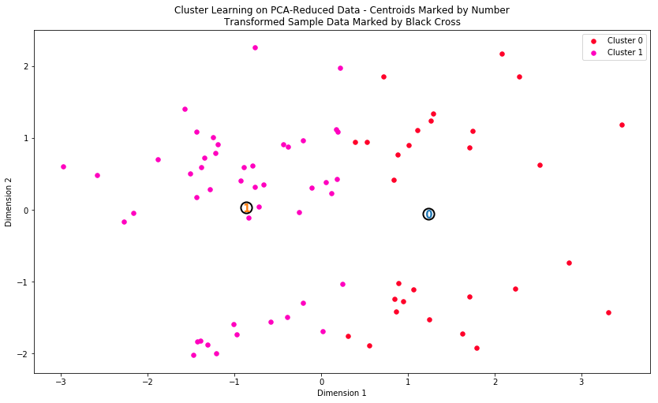

```python
# Visualizando o resultado da clusterização
vs.cluster_results(reduced_data, preds, centers)
```

No início do projeto foi retirado o atributo que indica se a partida foi uma vitória (*win*) ou derrota (*defeat*). Abaixo é utilizado este atributo para visualizar a distribuição gerada a partir dos dados iniciais a fim de compararmos com o resultado da clusterização criada.

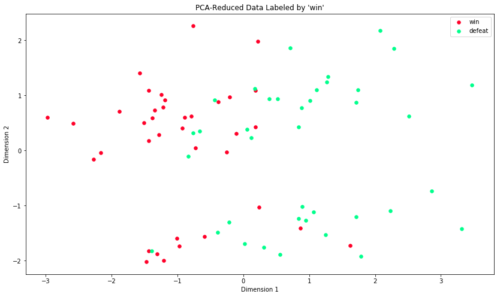

```python
# Mostre os resultados do clustering baseado nos dados do 'Channel'
vs.win_results(reduced_data, outliers)
```

## Conclusão

Julgo satisfatório o resultado obtido a partir da clusterização utilizada se compararmos com o gráfico apresentado utilizando o atributo `win` retirado no início do projeto. Apesar de errar a classificação de alguns pontos, o mesmo classificou a maioria corretamente. Segue abaixo o valor de acurácia obtido.

```python
print('Valor de acurácia obtido: {:.2f}%'.format(mlf.get_accuracy(preds, outliers)))
```

```
Valor de acurácia obtido: 82.67%
```

Imagino que essas "classificações erradas" são provenientes de jogos onde perdi, mas tive um bom desempenho e também de jogos que ganhei e meu desempenho foi equivalente ao de uma derrota. Estas situações são normais de jogos, afinal um dia você "carrega" e no outro você é "carregado".

Achei interessante a escolha de relevância de atributos e confesso que alguns me deixaram surpresos, como por exemplo o `totalHeal`. Este demonstrou possuir uma boa correlação com outros atributos importantes para uma partida de League of Legends, como por exemplo `damageDealtToObjectives`, afinal quanto mais objetivos um time levar, maior a chance de vitória. Com certeza nas minhas próximas partidas vou me "antenar" mais sobre o meu `totalHeal` durante o jogo e também dar mais valor aos dragões do oceano e à itens que ajudam na taxa de cura ou que ajudam a curar fora de combate.

Por fim espero também utilizar a análise feita para os quatro primeiros PCA's encontrados para ajudar a entender melhor a minha *gameplay* e a inclusive melhorá-la. Essas análises me mostraram que tenho uma característica de um jogador que de certa forma foca mais no individual do que no coletivo e isto já é um ponto que posso melhorar para tentar ganhar mais!

Apesar de uma análise relativamente simples e pela pequena quantidade de dados utilizada fiquei muito feliz com o resultado e tenho certeza de que isso me ajudará a ser um melhor jogador de League of Legends!